# Explore and Summarize Data

# Multivariate Plots

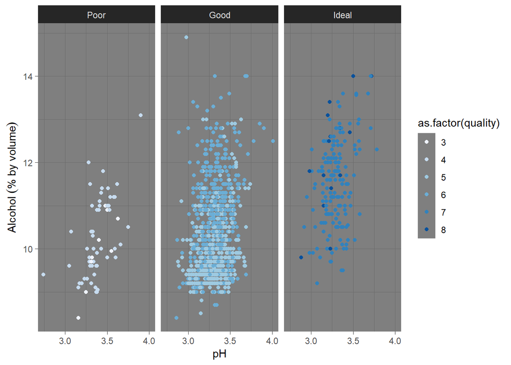

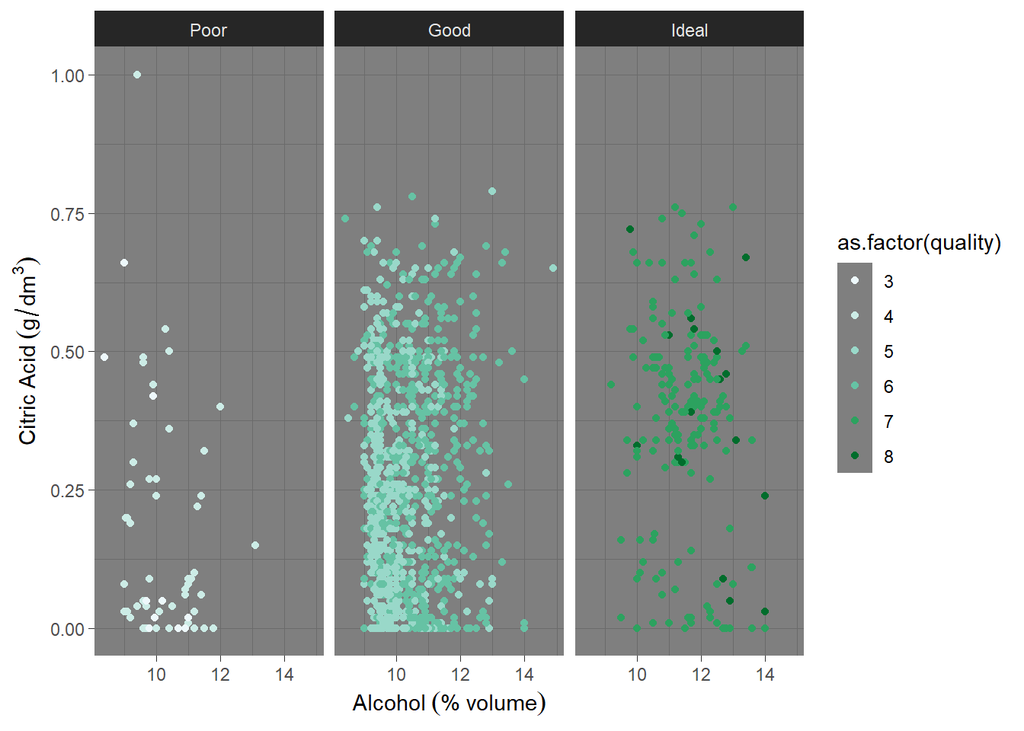

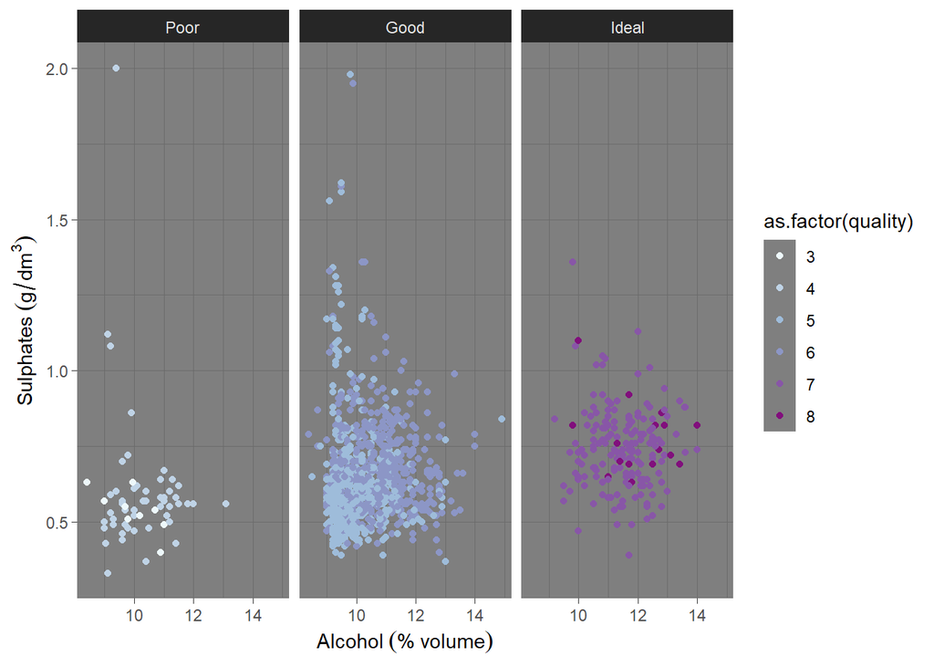

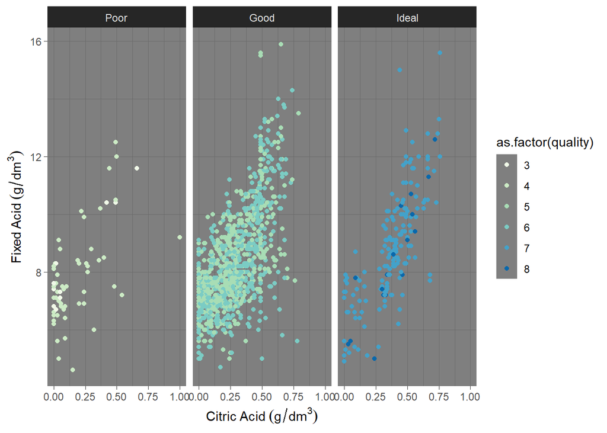

### Linear Modelling

In the next step, the goal is to check if there is linear model that fits along these four variables.

```
##
## Calls:
## m1: lm(formula = as.numeric(quality) ~ alcohol, data = rw_data)
## m2: lm(formula = as.numeric(quality) ~ alcohol + sulphates, data = rw_data)
## m3: lm(formula = as.numeric(quality) ~ alcohol + sulphates + volatile.acidity,
##     data = rw_data)
## m4: lm(formula = as.numeric(quality) ~ alcohol + sulphates + volatile.acidity +
##     citric.acid, data = rw_data)
## m5: lm(formula = as.numeric(quality) ~ alcohol + sulphates + volatile.acidity +
##     citric.acid + fixed.acidity, data = rw_data)
## m6: lm(formula = as.numeric(quality) ~ alcohol + sulphates + volatile.acidity +
##     citric.acid + fixed.acidity + pH, data = rw_data)
##
## ===================================================================================================
##                          m1           m2           m3           m4           m5           m6
## ---------------------------------------------------------------------------------------------------
##   (Intercept)           1.742***     1.262***     2.529***     2.558***     2.041***     2.925***
##                        (0.223)      (0.226)      (0.250)      (0.256)      (0.288)      (0.722)
##   alcohol               0.372***     0.355***     0.317***     0.318***     0.332***     0.339***
##                        (0.021)      (0.021)      (0.020)      (0.020)      (0.020)      (0.021)
##   sulphates                          0.992***     0.611***     0.624***     0.617***     0.609***
##                                     (0.134)      (0.133)      (0.135)      (0.134)      (0.134)
##   volatile.acidity                               -1.173***    -1.210***    -1.282***    -1.267***
##                                                  (0.118)      (0.136)      (0.136)      (0.137)
##   citric.acid                                                 -0.070       -0.488**     -0.512**
##                                                               (0.130)      (0.169)      (0.170)
##   fixed.acidity                                                             0.062***     0.050**
##                                                                            (0.016)      (0.019)
##   pH                                                                                    -0.257
##                                                                                         (0.192)
## ---------------------------------------------------------------------------------------------------
##   R-squared             0.242        0.283        0.351        0.351        0.361        0.362
##   adj. R-squared        0.241        0.282        0.349        0.348        0.358        0.358
##   sigma                 0.693        0.674        0.642        0.642        0.638        0.637
##   F                   305.431      188.903      171.948      128.936      107.614       90.049
##   p                     0.000        0.000        0.000        0.000        0.000        0.000
##   Log-likelihood    -1007.912     -981.039     -933.642     -933.498     -926.088     -925.191
##   Deviance            459.445      434.405      393.520      393.401      387.369      386.644
##   AIC                2021.824     1970.078     1877.285     1878.996     1866.177     1866.381
##   BIC                2036.421     1989.542     1901.614     1908.192     1900.238     1905.308
##   N                   959          959          959          959          959          959
## ===================================================================================================
```

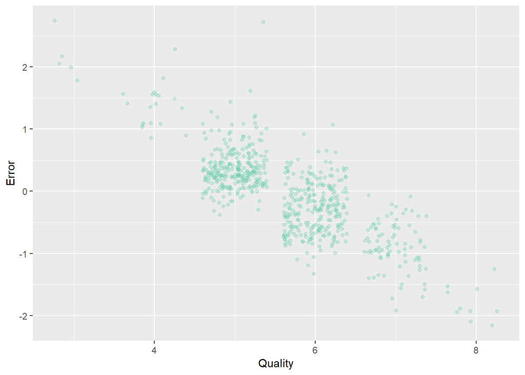

### Analysis of the Multivariate Plots

### Observations

Alcohol and Sulphates have positive correlation with quality of wine. Citric acid has a weak correlation with quality of wine.

### Analysis of the Linear Models

# Final Plots and Summary

### Plot One : Relation between Alcohol and wine quality

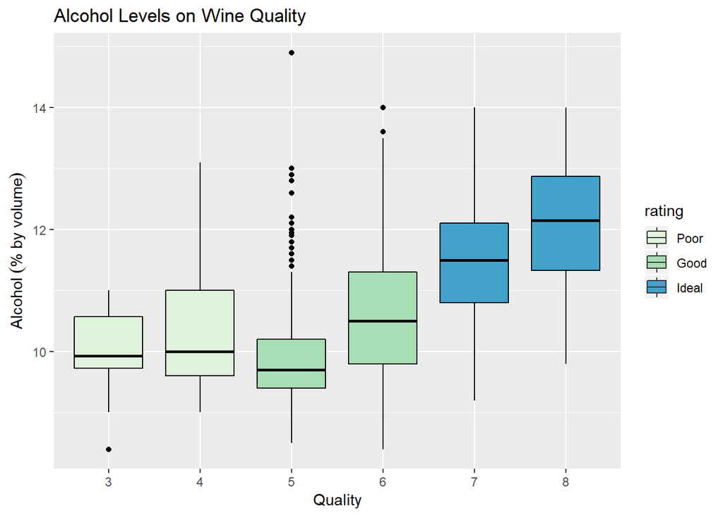

#### Plot One Analysis

From the above plot, we can see a positive correlation between alcohol and quality. This means higher alcohol content gives better wine quality.

### Plot Two : Relation between Acid and wine quality

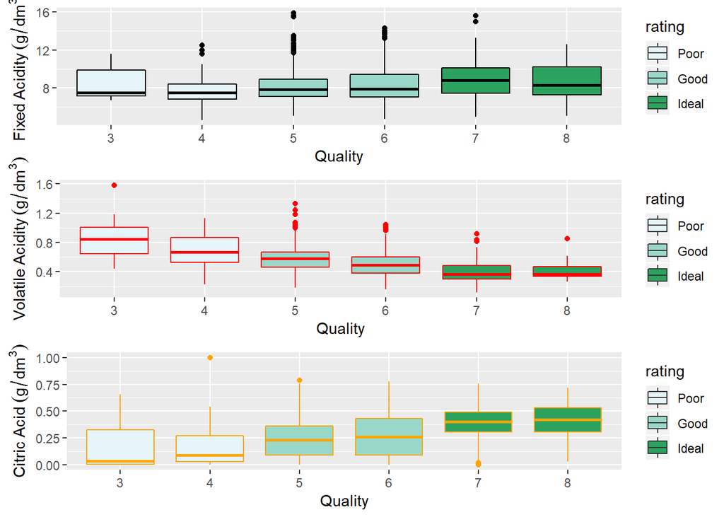

### Plot Three : Relation between Ideal and poor wine

[figure not shown]

#### Plot Three Analysis

The higher alcohol and sulphate content is associated with better wines. There is a positive correlation between alcohol,sulphates and quality of wine. This plot is similar to the positively correlated plot between Citric acid and Quality of wine.

# Reflection

In the initial part of the EDA, I came across the ‘citric acid’ variable which had a lot of zero values. One of the possible reasoning could be that this component is not really part of each and every wine. Very few wine makers add this as a component.

Most of the plots were normally distributed. Some needed a Log 10 transformation for the normal distribution as well as the long tailed data.

For the uni-variate analysis, few factors that had a relationship between quality were Alcohol, Sulfates and acidity. Further investigation showed a contradiction. The pH value was increasing with increase in acidity. Its contradicting because higher pH means higher basicity.

This is another example of Simpson’s paradox. According to Wikipedia, “Simpson’s paradox, or the Yule-Simpson effect, is a phenomenon in probability and statistics, in which a trend appears in several different groups of data but disappears or reverses when these groups are combined. It is sometimes given the descriptive title reversal paradox or amalgamation paradox”"

In the multivariate analysis, a lot of different variables were investigated for relationship with other variables. One of the results that came up was that density was not having any positive correlation with quality of wine.

So to summarize, the major contributors to better wine quality are alcohol, acidity and sulphates.Please note, all these conclusions are based on the fact that this data set is valid and the observations are legit. The more data points we have the better out conclusions will be. For now, we are limited by the samples in this data set.

For a better analysis, we should collect more observations and more features that can affect the quality like temperature, geographic locations,type of soil used for fruits, type of wood used in the casket etc. This will put a lot more data points to analyze and find relationships between these variables. We can also add the type of grapes or fruit ingredient used. Having data about how many days it takes to get the wine ready for bottling would add another dimension for analysis.

Challenges:

To begin with the whole project is with a new language R. That was the biggest challenge. I had to repeat the Udacity videos a lot. Having learnt Python similarly that experience helped. Google and Stack overflow were helpful. The goal now would be to continue looking at different data sets and learn more about R and its packages.